# Working with Bioconductor objects

Author

[Michael Love](http://mikelove.github.io)

Why use Bioconductor? From a user perspective, the answer is clear: because many statisticians, bioinformaticians, and computer scientists have spent time writing methods and algorithms specifically for biological/genomic data. A reason for this, and why many people have contributed to this project, is that there is a shared infrastructure for common data types. This infrastructure is built up of object classes. An example of a class is *GRanges* (stands for “genomic ranges”), which is a way to specify a set of ranges in a particular genome, e.g. from basepair 101 to basepair 200 on chromosome 1 of the human genome (version 38). What’s an object? Well everything in R is an object, but usually when we talk about Bioconductor objects, we mean data structures containing many attributes, so more complex than a vector or matrix. And the objects have specific *methods* that help you either access the information in the object, run analyses on the object, plot the object, etc. Bioconductor also allows for *inheritance*, which means that you can define a class of object that inherits the structure and methods of a *superclass* on which it depends. This last point is mostly important for people who are developing new software for Bioconductor (maybe that’s you!)

# Getting started with Bioconductor

Before we get started, you need to know how to install Bioconductor packages. The most important details are:

- Bioconductor is a package repository, like CRAN
- All Bioconductor packages should be installed following the instructions here: https://bioconductor.org/install (the only real exception is if you want to obtain [Linux binaries](https://eddelbuettel.github.io/r2u/), but for working on Windows or Mac, you should stick to the above instructions)
- Bioconductor packages are linked in their versions, both to each other and to the version of R
- Bioconductor’s installation function will look up your version of R and give you the appropriate versions of Bioconductor packages
- If you want the latest version of Bioconductor, you need to use the latest version of R

**Our version of R/Bioconductor**

We will be using this version of R and Bioconductor:

```r
print(paste(
  "R version:",
  getRversion()
))
```

```
[1] "R version: 4.6.0"
```

```r
print(paste(
  "Bioc version:",
  BiocManager::version()
))
```

```
[1] "Bioc version: 3.23"
```

How do you know if a package is a Bioconductor package? For one thing, you can just google the package name and you’ll see either CRAN or Bioconductor as a first result (packages must be in one or the other, they are not allowed to be on both repositories). But also, you can use Bioconductor’s installation function to install any packages, even ones on CRAN. By the way, you can install multiple packages at once by making a string vector: `BiocManager::install(c("foo","bar"))`

Why all this stress on versioning? This is because the packages in Bioconductor are highly *interdependent*, and also some are very dependent on R internals. So that the project can guarantee the code will run and not give errors on many systems (Linux, Mac and Windows have support for the majority of Bioconductor packages), new development is locked into cycles, such that a *release* of Bioconductor shouldn’t contain any two packages which conflict and could potentially cause errors.

Details: of course, Bioconductor is also a [project](https://www.ncbi.nlm.nih.gov/pmc/articles/PMC4509590), made up of people. There is a *core team* which is supported by an NIH grant, and developers who contribute to the open source Bioconductor packages. There are also yearly [conferences](https://www.bioconductor.org/help/events/) (one in US, one in Europe, and one in Asia, etc.).

# Working with Bioconductor objects

We will introduce the core Bioconductor objects this week. In this particular document, we will discuss one of the most important classes of object, which is the *SummarizedExperiment*, or SE.

SEs have the structure:

- a matrix of data, rows are genomic features, and columns are samples
- a table of data about the samples (columns)
- a table of data about the features (rows)

A diagram of this 3-part structure can be found [here](https://www.ncbi.nlm.nih.gov/pmc/articles/PMC4509590/figure/F2/).

In SE, the 3 parts of the object are called 1) `assay`, 2) `colData` and 3) `rowData` or `rowRanges`.

**Note**: There was a class of object that came before the SE, called the *ExpressionSet*, which was used primarily to store *microarray* data. Here we will skip over the *ExpressionSet*, and just look at SEs.

It helps to start by making a small toy SE, to see how the pieces come together. (Often you won’t make an SE manually, but it will be downloaded from an external source, or generated by a function that you call, e.g. `tximeta` or some other data loading function.)

```r
library(SummarizedExperiment)
col_data <- data.frame(sample=factor(1:6),
                       condition=factor(c("A","A","B","B","C","C")),
                       treated=factor(rep(0:1,3)))
col_data
```

```
  sample condition treated
1      1         A       0
2      2         A       1
3      3         B       0
4      4         B       1
5      5         C       0
6      6         C       1
```

An important aspect of SEs is that the rows can optionally correspond to particular set of *GRanges*, e.g. a row of an SE could give the number of RNA-seq reads that can be assigned to a particular gene, and the row could also have metadata in the 3rd slot including, e.g. location of the gene in the genome. In this case, we use the `rowRanges` slot to specify the information.

If we don’t have ranges, we can just put a table on the “side” of the SE by specifying `rowData`.

I will show in the example though how to provide `rowRanges`. Let’s use the first 10 genes from the UCSC hg38 knownGene annotation. The following code loads a database, pulls out all the genes (as *GRanges*), removes extra “non-standard” chromosomes, and then subsets to the first 10 genes.

```r
library(TxDb.Hsapiens.UCSC.hg38.knownGene)
txdb <- TxDb.Hsapiens.UCSC.hg38.knownGene
suppressMessages({
  g <- sort(genes(txdb))
})
g <- GenomeInfoDb::keepStandardChromosomes(g, pruning.mode="coarse")
row_ranges <- g[1:10]
```

We will make up some simulated “expression” measurements, and then store these in the SE. I call `list` so I can name the matrix, otherwise it would not be named.

```r
exprs <- matrix(rnorm(6 * 10), ncol=6, nrow=10)
se <- SummarizedExperiment(assay = list("exprs" = exprs),
                           colData = col_data,
                           rowRanges = row_ranges)
se
```

```
class: RangedSummarizedExperiment
dim: 10 6
metadata(0):
assays(1): exprs
rownames(10): 100287102 107985730 ... 400728 643837
rowData names(1): gene_id
colnames: NULL
colData names(3): sample condition treated
```

We see this object has one named matrix. The object could have multiple matrices (as long as these are the same shape). In that case you could access the first with `assay` and in general by name, e.g. `assay(se, "exprs")` or equivalently `assays(se)[["exprs"]]` .

```r
assayNames(se)
```

```
[1] "exprs"
```

Finally, if we wanted to add data onto the rows, for example, the score of a test on the matrix data, we use the metadata columns function, or `mcols`:

```r
mcols(se)$score <- rnorm(10)
mcols(se)
```

```
DataFrame with 10 rows and 2 columns
              gene_id      score
          <character>  <numeric>
100287102   100287102  1.1418449
107985730   107985730  1.2985157
100302278   100302278  1.6422630
79501           79501 -0.2848453
102725121   102725121  2.6633842
124903815   124903815  0.0929827
105378580   105378580 -0.4121722
124903817   124903817  0.0185722
400728         400728  0.0207893
643837         643837 -1.2392003
```

Adding data to the column metadata is even easier, we can just use `$`:

```r
se$librarySize <- runif(6,1e6,2e6)
colData(se)
```

```
DataFrame with 6 rows and 4 columns
    sample condition  treated librarySize
  <factor>  <factor> <factor>   <numeric>
1        1         A        0     1176159
2        2         A        1     1081057
3        3         B        0     1275764
4        4         B        1     1198264
5        5         C        0     1807873
6        6         C        1     1631031
```

# Using the ranges of a SE

How does this additional functionality of the `rowRanges` facilitate faster data analysis? Suppose we are working with another data set besides `se` and we find a region of interest on chromsome 1. If we want to pull out the expression data for that region, we just ask for the subset of `se` that overlaps. First we build the query region, and then use the *GRanges* function `overlapsAny` within single square brackets (like you would subset any matrix-like object:

```r
query <- GRanges("chr1", IRanges(5000,35000))
se_sub <- se[overlapsAny(se, query), ]
```

We could have equivalently used the shorthand code:

```r
se_sub <- se[se %over% query,]
```

We get just the overlapping ranges, and the corresponding rows of the SE:

```r
rowRanges(se_sub)
```

```
GRanges object with 3 ranges and 2 metadata columns:
            seqnames      ranges strand |     gene_id     score
               <Rle>   <IRanges>  <Rle> | <character> <numeric>
  100287102     chr1 11121-14421      + |   100287102   1.14184
  107985730     chr1 28977-31109      + |   107985730   1.29852
  100302278     chr1 30366-30503      + |   100302278   1.64226
  -------
  seqinfo: 25 sequences (1 circular) from hg38 genome
```

```r
assay(se_sub)
```

```
                [,1]       [,2]       [,3]       [,4]      [,5]     [,6]
100287102  1.2415408 -2.8962065 -0.5820229  0.2291434 1.1412485 2.853652
107985730  2.0337348  0.6713310  0.5457085  2.0416815 1.5675024 1.422555
100302278 -0.3548704  0.1838906 -1.0552120 -0.8388115 0.6943347 2.125127
```

Another useful property is that we know metadata about the chromosomes, and the version of the genome. (If you were not yet aware, the basepair position of a given feature, say gene *XYZ*, will change between versions of the genome, as sequences are added or rearranged.)

```r
seqinfo(se)
```

```
Seqinfo object with 25 sequences (1 circular) from hg38 genome:
  seqnames seqlengths isCircular genome
  chr1      248956422      FALSE   hg38
  chr2      242193529      FALSE   hg38
  chr3      198295559      FALSE   hg38
  chr4      190214555      FALSE   hg38
  chr5      181538259      FALSE   hg38
  ...             ...        ...    ...
  chr21      46709983      FALSE   hg38
  chr22      50818468      FALSE   hg38
  chrX      156040895      FALSE   hg38
  chrY       57227415      FALSE   hg38
  chrM          16569       TRUE   hg38
```

# Downloading SE data

We previously introduced the computational project, called [recount2](https://jhubiostatistics.shinyapps.io/recount/), which performs a basic summarization of public data sets with gene expression data. We will use data from *recount2* again.

This dataset contains RNA-seq samples from human airway epithelial cell cultures. The paper is [here](https://www.ncbi.nlm.nih.gov/pubmed/25706956). The structure of the experiment was that, cell cultures from 6 asthmatic and 6 non-asthmatics donors were treated with viral infection or left untreated (controls). So we have 2 samples (control or treated) for each of the 12 donors.

```r
library(here)
url <- "http://duffel.rail.bio/recount/SRP046226/rse_gene.Rdata"
file <- here("bioc","asthma.rda")
if (!file.exists(file)) download.file(url, file)
load(file)
```

We use a custom function to produce a matrix which a count of RNA fragments for each gene (rows) and each sample (columns).

(Recount project calls these objects `rse` for *RangedSummarizedExperiment*, meaning it has `rowRanges` information.)

```r
source(here("bioc","my_scale_counts.R"))
rse <- my_scale_counts(rse_gene)
```

We can take a peek at the column data:

```r
colData(rse)[,1:6]
```

```
DataFrame with 24 rows and 6 columns
               project      sample  experiment         run read_count_as_reported_by_sra
           <character> <character> <character> <character>                     <integer>
SRR1565926   SRP046226   SRS694613   SRX692912  SRR1565926                      12866750
SRR1565927   SRP046226   SRS694614   SRX692913  SRR1565927                      12797108
SRR1565928   SRP046226   SRS694615   SRX692914  SRR1565928                      13319016
SRR1565929   SRP046226   SRS694616   SRX692915  SRR1565929                      13725752
SRR1565930   SRP046226   SRS694617   SRX692916  SRR1565930                      10882416
...                ...         ...         ...         ...                           ...
SRR1565945   SRP046226   SRS694632   SRX692931  SRR1565945                      13791854
SRR1565946   SRP046226   SRS694633   SRX692932  SRR1565946                      13480842
SRR1565947   SRP046226   SRS694634   SRX692933  SRR1565947                      13166594
SRR1565948   SRP046226   SRS694635   SRX692934  SRR1565948                      13320398
SRR1565949   SRP046226   SRS694636   SRX692935  SRR1565949                      13002276
           reads_downloaded
                  <integer>
SRR1565926         12866750
SRR1565927         12797108
SRR1565928         13319016
SRR1565929         13725752
SRR1565930         10882416
...                     ...
SRR1565945         13791854
SRR1565946         13480842
SRR1565947         13166594
SRR1565948         13320398
SRR1565949         13002276
```

# Parsing sample information

The information we are interested in is contained in the `characteristics` column (which is a character list).

```r
class(rse$characteristics)
```

```
[1] "CompressedCharacterList"
attr(,"package")
[1] "IRanges"
```

```r
rse$characteristics[1:3]
```

```
CharacterList of length 3
[[1]] cell type: Isolated from human trachea-bronchial tissues passages: 2 disease state: asthmatic treatment: HRV16
[[2]] cell type: Isolated from human trachea-bronchial tissues passages: 2 disease state: asthmatic treatment: HRV16
[[3]] cell type: Isolated from human trachea-bronchial tissues passages: 2 disease state: asthmatic treatment: HRV16
```

```r
rse$characteristics[[1]]
```

```
[1] "cell type: Isolated from human trachea-bronchial tissues"
[2] "passages: 2"
[3] "disease state: asthmatic"
[4] "treatment: HRV16"
```

We can pull out the 3 and 4 element using the `sapply` function and the square bracket function. I know this syntax looks a little funny, but it’s really just saying, use the single square bracket, pull out the third element (or fourth element).

```r
rse$condition <- sapply(rse$characteristics, `[`, 3)
rse$treatment <- sapply(rse$characteristics, `[`, 4)
table(rse$condition, rse$treatment)
```

```
                               treatment: HRV16 treatment: Vehicle
  disease state: asthmatic                    6                  6
  disease state: non-asthmatic                6                  6
```

The following code I use to clean up the condition and treatment variables:

```r
library(stringr)
rse$condition <- rse$condition |>
  str_remove("disease state: ") |>
  str_replace("-", ".") |>
  factor()
rse$treatment <- rse$treatment |>
  str_remove("treatment: ") |>
  factor()
```

Now we have:

```r
table(rse$condition, rse$treatment)
```

```
                HRV16 Vehicle
  asthmatic         6       6
  non.asthmatic     6       6
```

# Looking at the genes and their ranges

Let’s see what the `rowRanges` of this experiment look like:

```r
rowRanges(rse)
```

```
GRanges object with 58037 ranges and 3 metadata columns:
                     seqnames              ranges strand |            gene_id bp_length
                        <Rle>           <IRanges>  <Rle> |        <character> <integer>
  ENSG00000000003.14     chrX 100627109-100639991      - | ENSG00000000003.14      4535
   ENSG00000000005.5     chrX 100584802-100599885      + |  ENSG00000000005.5      1610
  ENSG00000000419.12    chr20   50934867-50958555      - | ENSG00000000419.12      1207
  ENSG00000000457.13     chr1 169849631-169894267      - | ENSG00000000457.13      6883
  ENSG00000000460.16     chr1 169662007-169854080      + | ENSG00000000460.16      5967
                 ...      ...                 ...    ... .                ...       ...
   ENSG00000283695.1    chr19   52865369-52865429      - |  ENSG00000283695.1        61
   ENSG00000283696.1     chr1 161399409-161422424      + |  ENSG00000283696.1       997
   ENSG00000283697.1     chrX 149548210-149549852      - |  ENSG00000283697.1      1184
   ENSG00000283698.1     chr2 112439312-112469687      - |  ENSG00000283698.1       940
   ENSG00000283699.1    chr10   12653138-12653197      - |  ENSG00000283699.1        60
                              symbol
                     <CharacterList>
  ENSG00000000003.14          TSPAN6
   ENSG00000000005.5            TNMD
  ENSG00000000419.12            DPM1
  ENSG00000000457.13           SCYL3
  ENSG00000000460.16        C1orf112
                 ...             ...
   ENSG00000283695.1            <NA>
   ENSG00000283696.1            <NA>
   ENSG00000283697.1    LOC101928917
   ENSG00000283698.1            <NA>
   ENSG00000283699.1         MIR4481
  -------
  seqinfo: 25 sequences (1 circular) from an unspecified genome; no seqlengths
```

```r
seqinfo(rse)
```

```
Seqinfo object with 25 sequences (1 circular) from an unspecified genome; no seqlengths:
  seqnames seqlengths isCircular genome
  chr1           <NA>       <NA>   <NA>
  chr2           <NA>       <NA>   <NA>
  chr3           <NA>       <NA>   <NA>
  chr4           <NA>       <NA>   <NA>
  chr5           <NA>       <NA>   <NA>
  ...             ...        ...    ...
  chr21          <NA>       <NA>   <NA>
  chr22          <NA>       <NA>   <NA>
  chrX           <NA>       <NA>   <NA>
  chrY           <NA>       <NA>   <NA>
  chrM           <NA>       TRUE   <NA>
```

The `rowRanges` here were determined by the quantification method that the *recount2* authors used. We don’t know what the genome is from the `seqinfo`, but we can see from the [recount2 website](https://jhubiostatistics.shinyapps.io/recount/) the following information:

> The RangedSummarizedExperiment object for the counts summarized at the gene level using the Gencode v25 (GRCh38.p7, CHR) annotation.

```r
library(Seqinfo)
si_obj <- Seqinfo::Seqinfo(genome="hg38")
seqinfo(rse) <- si_obj[ seqlevels(rse) ]
seqinfo(rse)
```

```
Seqinfo object with 25 sequences (1 circular) from hg38 genome:
  seqnames seqlengths isCircular genome
  chr1      248956422      FALSE   hg38
  chr2      242193529      FALSE   hg38
  chr3      198295559      FALSE   hg38
  chr4      190214555      FALSE   hg38
  chr5      181538259      FALSE   hg38
  ...             ...        ...    ...
  chr21      46709983      FALSE   hg38
  chr22      50818468      FALSE   hg38
  chrX      156040895      FALSE   hg38
  chrY       57227415      FALSE   hg38
  chrM          16569       TRUE   hg38
```

```r
rowRanges(rse)[1]
```

```
GRanges object with 1 range and 3 metadata columns:
                     seqnames              ranges strand |            gene_id bp_length
                        <Rle>           <IRanges>  <Rle> |        <character> <integer>
  ENSG00000000003.14     chrX 100627109-100639991      - | ENSG00000000003.14      4535
                              symbol
                     <CharacterList>
  ENSG00000000003.14          TSPAN6
  -------
  seqinfo: 25 sequences (1 circular) from hg38 genome
```

```r
seqinfo(rse)["chrX"]
```

```
Seqinfo object with 1 sequence from hg38 genome:
  seqnames seqlengths isCircular genome
  chrX      156040895      FALSE   hg38
```

```r
shift(rowRanges(rse)[1], 55e6)
```

```
GRanges object with 1 range and 3 metadata columns:
                     seqnames              ranges strand |            gene_id bp_length
                        <Rle>           <IRanges>  <Rle> |        <character> <integer>
  ENSG00000000003.14     chrX 155627109-155639991      - | ENSG00000000003.14      4535
                              symbol
                     <CharacterList>
  ENSG00000000003.14          TSPAN6
  -------
  seqinfo: 25 sequences (1 circular) from hg38 genome
```

```r
shift(rowRanges(rse)[1], 57e6)
```

```
GRanges object with 1 range and 3 metadata columns:
                     seqnames              ranges strand |            gene_id bp_length
                        <Rle>           <IRanges>  <Rle> |        <character> <integer>
  ENSG00000000003.14     chrX 157627109-157639991      - | ENSG00000000003.14      4535
                              symbol
                     <CharacterList>
  ENSG00000000003.14          TSPAN6
  -------
  seqinfo: 25 sequences (1 circular) from hg38 genome
```

# Adding gene metadata from a GTF file

One piece of metadata we might want to add to the rows of our SE is the gene biotype, e.g. whether a gene is protein-coding, a lncRNA, a pseudogene, etc. This information is available in the GENCODE annotation GTF file. Here we use *rtracklayer* to import the GTF directly, keeping only the gene-level entries. We will see other ways to work with GTF files and annotation databases later in the Bioconductor section of the course. The GTF is ~37 Mb.

```r
library(rtracklayer)
# GENCODE v25
gtf_url <- "https://ftp.ebi.ac.uk/pub/databases/gencode/Gencode_human/release_25/gencode.v25.annotation.gtf.gz"
gtf_file <- here("bioc", "gencode.v25.gtf.gz")
if (!file.exists(gtf_file)) download.file(gtf_url, gtf_file)
genes_gtf <- rtracklayer::import(gtf_file, feature.type="gene")
```

The `feature.type` argument limits the import to gene-level rows, so we avoid parsing the full multi-million line file. The result is ranges with metadata columns from the GTF, including `gene_type`. Both the GTF and our `rse` use versioned GENCODE gene IDs (e.g. `ENSG00000000003.14`), so we can match them directly.

```r
m <- match(rownames(rse), genes_gtf$gene_id)
mcols(rse)$gene_type <- genes_gtf$gene_type[m]
tab <- table(mcols(rse)$gene_type)
head(sort(tab, decreasing = TRUE),10)
```

```
        protein_coding   processed_pseudogene                lincRNA              antisense
                 19950                  10275                   7539                   5530
unprocessed_pseudogene               misc_RNA                  snRNA                  miRNA
                  2663                   2213                   1900                   1569
                   TEC                 snoRNA
                  1048                    944
```

# Visualizing count matrix data in a SE

We will discuss transformations and normalization in a following section, but here we will just use a transformation so that we can compute meaningful distances on count data. We build a *DESeqDataSet* and then specify the experimental design using a `~` and the variables that we expect to produce differences in the counts. (These variables are used to assess how much technical variability is in the data, but not used in the transformation function itself.)

```r
library(DESeq2)
dds <- DESeqDataSet(rse, ~condition + treatment)
```

We use this function, which implements a *variance stabilizing transformation* (more on this next time):

```r
vsd <- vst(dds)
```

We calculate the variance across all samples (on the transformed data):

```r
library(matrixStats)
rv <- rowVars(assay(vsd))
o <- order(rv, decreasing=TRUE)[1:100]
```

Finally, before plotting a heatmap, we extract the covariates that we want to annotated the top of the plot.

```r
anno_col <- as.data.frame(colData(vsd)[,c("condition","treatment")])
anno_col
```

```
               condition treatment
SRR1565926     asthmatic     HRV16
SRR1565927     asthmatic     HRV16
SRR1565928     asthmatic     HRV16
SRR1565929     asthmatic     HRV16
SRR1565930     asthmatic     HRV16
SRR1565931     asthmatic     HRV16
SRR1565932     asthmatic   Vehicle
SRR1565933     asthmatic   Vehicle
SRR1565934     asthmatic   Vehicle
SRR1565935     asthmatic   Vehicle
SRR1565936     asthmatic   Vehicle
SRR1565937     asthmatic   Vehicle
SRR1565938 non.asthmatic     HRV16
SRR1565939 non.asthmatic     HRV16
SRR1565940 non.asthmatic     HRV16
SRR1565941 non.asthmatic     HRV16
SRR1565942 non.asthmatic     HRV16
SRR1565943 non.asthmatic     HRV16
SRR1565944 non.asthmatic   Vehicle
SRR1565945 non.asthmatic   Vehicle
SRR1565946 non.asthmatic   Vehicle
SRR1565947 non.asthmatic   Vehicle
SRR1565948 non.asthmatic   Vehicle
SRR1565949 non.asthmatic   Vehicle
```

This code pull out the top of the transformed data by variance, and adds an annotation to the top of the plot. By default the rows and columns will be clustered by Euclidean distance. See `?pheatmap` for more details on this function (it’s a very detailed manual page).

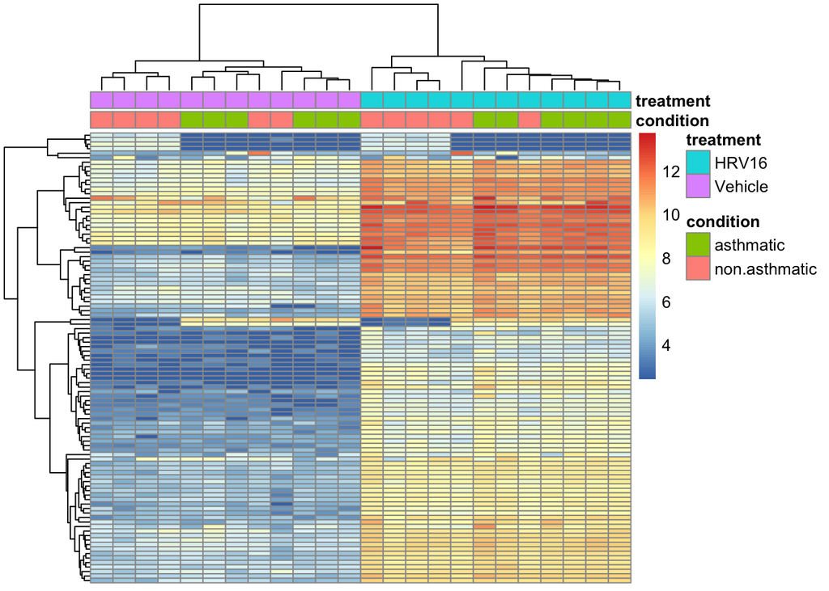

```r
library(pheatmap)
pheatmap(assay(vsd)[o,],
         annotation_col=anno_col,
         show_rownames=FALSE,
         show_colnames=FALSE)
```

We can also easily make a PCA plot with dedicated functions:

```
using ntop=500 top features by variance
```

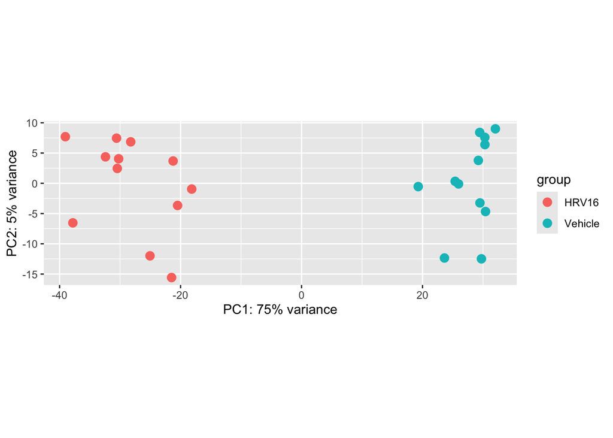

```r
plotPCA(vsd, intgroup="treatment")
```

# SingleCellExperiment

An example of a class that extends the SE is *SingleCellExperiment*. This is a special object type for looking at single cell data.

For more details, there is a free online book “Orchestrating Single Cell Analysis With Bioconductor” produced by a group within the Bioconductor Project, with lots of example analyses: [OSCA](http://bioconductor.org/books/3.15/OSCA.basic/).

Here we show a quick example of how this object extends the SE.

```r
library(SingleCellExperiment)
sce <- as(rse, "SingleCellExperiment")
sce
```

```
class: SingleCellExperiment
dim: 58037 24
metadata(0):
assays(1): counts
rownames(58037): ENSG00000000003.14 ENSG00000000005.5 ... ENSG00000283698.1
  ENSG00000283699.1
rowData names(4): gene_id bp_length symbol gene_type
colnames(24): SRR1565926 SRR1565927 ... SRR1565948 SRR1565949
colData names(23): project sample ... condition treatment
reducedDimNames(0):
mainExpName: NULL
altExpNames(0):
```

There are special functions dedicated to scaling the samples (we will discuss this technical aspect soon):

```r
library(scran)
sce <- computeSumFactors(sce)
sizeFactors(sce)
```

```
 [1] 0.7672143 0.8205514 0.8686567 0.9479224 0.6484723 0.9815079 1.0797070 1.0569889 1.4377886
[10] 0.9465292 1.4759422 1.2630195 0.8889808 1.0524670 0.9677885 0.8086102 0.8806503 0.8999780
[19] 0.9505805 1.0430322 1.2527967 0.9908707 0.5208294 1.4491155
```

Similarly, dedicated functions for transformations (the deprecation warning is ignorable for now, as of 2026 functions for single cell transformation are being migrated to new packages…)

```r
sce <- logNormCounts(sce)
```

```
Warning in .local(x, ...): 'normalizeCounts' is deprecated.
Use 'scrapper::normalizeCounts' instead.
See help("Deprecated")
```

```r
assayNames(sce)
```

```
[1] "counts"    "logcounts"
```

And dedicated functions and new slots for reduced dimensions. (Again ignore the deprecation warnings…)

```r
set.seed(1)
sce <- fixedPCA(sce, rank=5, subset.row=NULL)
```

```
Warning in fixedPCA(sce, rank = 5, subset.row = NULL): 'fixedPCA' is deprecated.
Use 'scrapper::runPca.se' instead.
See help("Deprecated")
```

```r
reducedDimNames(sce)
```

```
[1] "PCA"
```

We can manually get at the PCs:

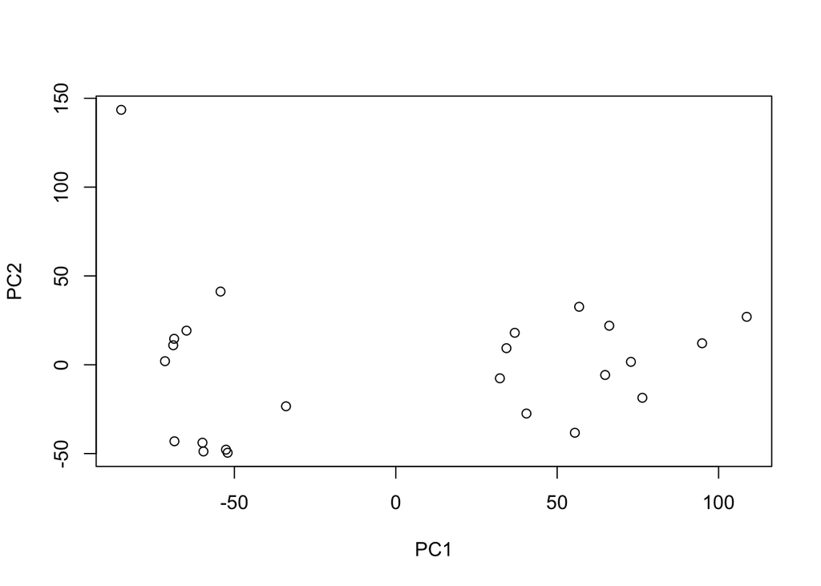

```r
pca <- reducedDim(sce, "PCA")
plot(pca[,1:2])
```

But we can more easily use dedicated visualization functions:

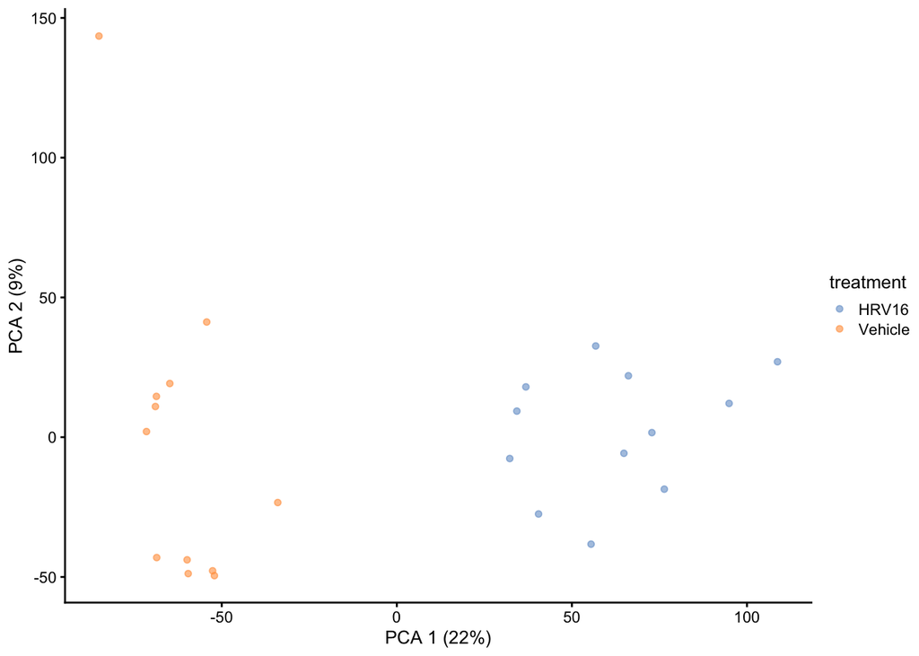

```r
library(scater)
plotReducedDim(sce, "PCA", color_by="treatment")
```

# Other specialized objects in Bioconductor

Some other specialized objects that build on the SummarizedExperiment include:

- SpatialExperiment[^1] with best practices outlined [here](https://lmweber.org/BestPracticesST/)
- QFeatures[^2] for high-throughput mass spectrometry
- MultiAssayExperiment[^3] for multiple experimental assays performed on an overlapping set of specimens, e.g. RNA-seq, copy number, DNA methylation, etc.
- MethylationArray[^4] for DNA methylation arrays
- TreeSummarizedExperiment[^5] for data with hierarchical or tree-like structure on the rows or columns

## Footnotes

[^1]: https://www.bioconductor.org/packages/SpatialExperiment
[^2]: https://www.bioconductor.org/packages/QFeatures
[^3]: https://www.bioconductor.org/packages/MultiAssayExperiment
[^4]: https://www.bioconductor.org/packages/minfi
[^5]: https://www.bioconductor.org/packages/TreeSummarizedExperiment